# Selecting foils for schemaVR3

Jörn Alexander Quent

November 02, 2018

# Aim of this document

In a separate step, I selected five sets for schemaVR3 ([click here](https://jaquent.github.io/2018/0917_schemaVR3_stimulusSelection.html)). However, I did not select foil along side target locations because we originally planned to drop the 3AFC but now we decided to keep it in ([click here to see discussion](https://jaquent.me/2018/10/21/2018-10-18-finalising-analysis-and-design/)).

In this document, I will therefore select foil locations for the pre-selected sets.

# Preparation

```r
# Pre-selected sets
setNum <- c(848, 498, 388, 246, 111)
sets   <- read.csv("schemaVR3_sets.csv")

# Loading normative data
subNo                <- 1:6
N                    <- length(subNo)
numberObjects        <- 20
kitchenOjects        <- 1:12
numberKitchenObjects <- length(kitchenOjects)
nonKitchenObjets     <- 13:30
locationRatings      <- array(data = NA, dim = c(numberObjects, numberObjects, N))

fileLocation <- '/home/aq01/Projects/schemaVR/schemaVR3/preparation/schemaVR3_stimulusSelection/data/locationRatings_'

# Sequently loading data
for(i in 1:N){
  locationRatings[,,i] <- matrix(scan(paste(fileLocation,
                                            as.character(subNo[i]) ,
                                            '.dat', sep = '')),
                                 byrow = TRUE,
                                 ncol = 20)
}

# Calculating ranks
rankedRatings <- array(data = NA,
                       dim = c(numberObjects, numberObjects, N))

for(i in 1:N){
  rankedRatings[,,i] <- rank(locationRatings[,,i])
}

# Calculating mean rank per object/ location
meanRankedRatings <- apply(rankedRatings, 1:2, mean)

iterations      <- 100000
numSets         <- length(setNum)
totalIterations <- iterations*numSets
foils1          <- array(data = NA, dim = c(numSets, iterations, numberObjects))
foils2          <- array(data = NA, dim = c(numSets, iterations, numberObjects))
SS_foils        <- array(data = NA, dim = c(numSets, iterations))

startTime <- Sys.time()
index     <- 0
for(i in 1: numSets){
  for(j in 1:iterations){
    foils1[i, j,]  <- sample(numberObjects)
    foils2[i, j,]  <- sample(numberObjects)
    while(any(foils1[i, j,]  == foils2[i, j,]) | any(sets[i + 1] == foils2[i, j,]) | any(sets[i + 1] == foils2[i, j,])){
      foils1[i, j,]  <- sample(numberObjects)
      foils2[i, j,]  <- sample(numberObjects)
    }
    SS_foils[i, j] <- sum((meanRankedRatings[cbind(seq_along(as.numeric(unlist(sets[i + 1]))),  as.numeric(unlist(sets[i + 1])))] - meanRankedRatings[cbind(seq_along(foils1[i, j,]),  foils1[i, j,])])^2,
                          (meanRankedRatings[cbind(seq_along(as.numeric(unlist(sets[i + 1]))),  as.numeric(unlist(sets[i + 1])))] - meanRankedRatings[cbind(seq_along(foils2[i, j,]), foils2[i, j,])])^2)

    index <- index + 1
    progressDisplay(index, totalIterations, startTime)
  }
}

save.image(paste('data_selectingFoils_',format(Sys.time(), "%Y%m%d_%H%M"), '.RData', sep = ""))
```

# Selecting and checking foils

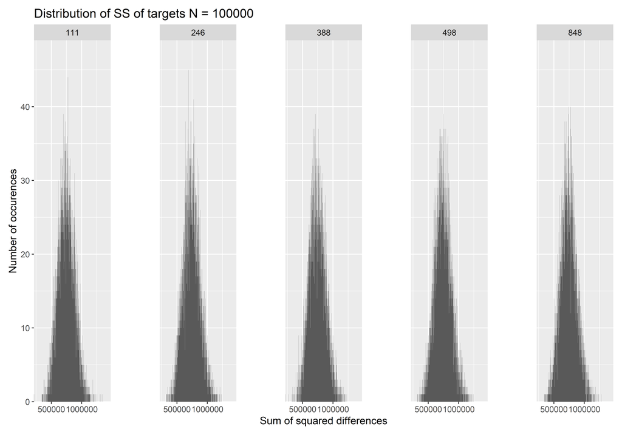

```r
# Loading data
load('data_selectingFoils_20181030_1753.RData')
objNam <- sets$Objects

# Visualising data
SS_foils_DF <- data.frame(set = rep(setNum, each = dim(SS_foils)[2]),
                          SS  = c(SS_foils))

# Displaying distributions
ggplot(SS_foils_DF, aes(SS)) +
  facet_grid(~ set) +
  geom_histogram(binwidth = 100) +
  theme(panel.margin = unit(2, "cm"),
        text = element_text(size = 12),
        plot.margin = margin(10, 10, 10, 10)) +
  labs(y = 'Number of occurences',
       x = 'Sum of squared differences',
       title = paste('Distribution of SS of targets N =', iterations)) +
  coord_cartesian(expand = FALSE)
```

As can be seen above the SS distribution for the different sets look similar. In the next step, I am select the foils with the smallest SS value and check their spread.

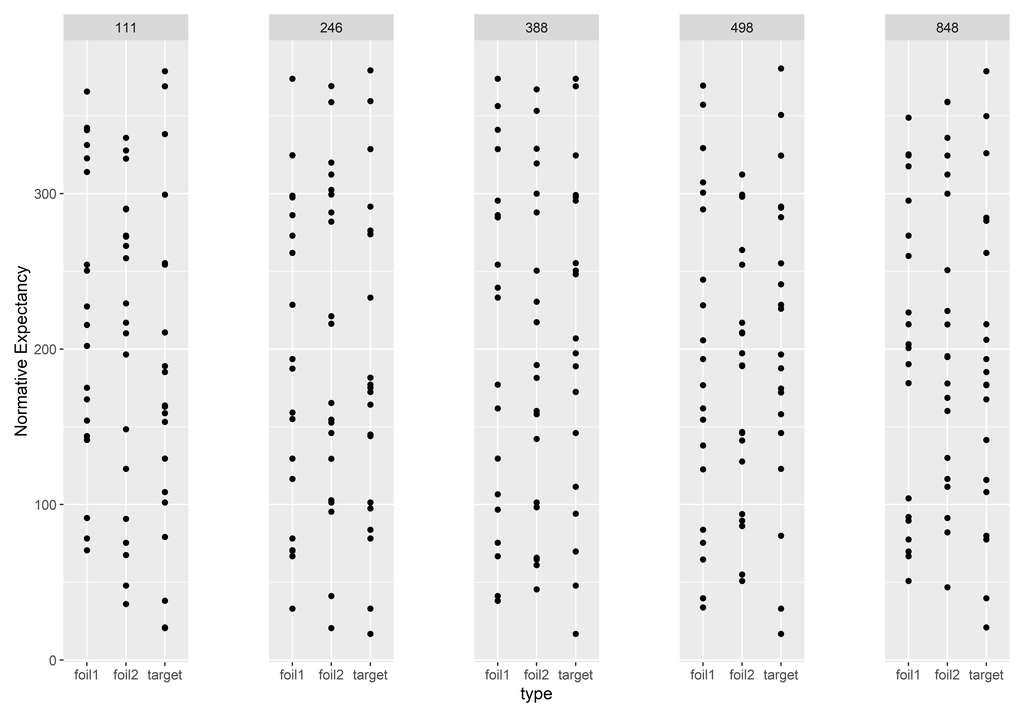

```r
# Getting min values and selecting sets
minValues <- apply(SS_foils, 1, min)
finalSets <- data.frame(set = rep(setNum, each = numberObjects),
                        objNum = rep(1:20, 5),
                        objNam = rep(objNam, 5),
                        target = c(sets$Set1, sets$Set2, sets$Set3, sets$Set4, sets$Set5),
                        foils1  = c(foils1[1, which(SS_foils[1,] == minValues[1]), ],
                                    foils1[1, which(SS_foils[2,] == minValues[2]), ],
                                    foils1[1, which(SS_foils[3,] == minValues[3]), ],
                                    foils1[1, which(SS_foils[4,] == minValues[4]), ],
                                    foils1[1, which(SS_foils[5,] == minValues[5]), ]),
                        foils2  = c(foils2[1, which(SS_foils[1,] == minValues[1]), ],
                                    foils2[1, which(SS_foils[2,] == minValues[2]), ],
                                    foils2[1, which(SS_foils[3,] == minValues[3]), ],
                                    foils2[1, which(SS_foils[4,] == minValues[4]), ],
                                    foils2[1, which(SS_foils[5,] == minValues[5]), ]))

finalSets$targetExp <- meanRankedRatings[cbind(rep(1:20, 5),  finalSets$target)]
finalSets$foils1Exp <- meanRankedRatings[cbind(rep(1:20, 5),  finalSets$foils1)]
finalSets$foils2Exp <- meanRankedRatings[cbind(rep(1:20, 5),  finalSets$foils2)]


# Visualise spread of individual sets
spreadData <- data.frame(set  = rep(finalSets$set, 3),
                         objNum = rep(1:20, 5*3),
                         location = c(finalSets$target, finalSets$foils1, finalSets$foils2),
                         type = rep(c('target', 'foil1','foil2'), each = numberObjects*5),
                         exp  = c(finalSets$targetExp, finalSets$foils1Exp, finalSets$foils2Exp))

ggplot(spreadData, aes(x = type, y = exp)) +
  facet_grid(~ set) +
  geom_point() +
  theme(panel.margin = unit(2, "cm"),
        text = element_text(size = 12),
        plot.margin = margin(10, 10, 10, 10)) +
  labs(y = 'Normative Expectancy')
```

To ensure that the foil location are not systematically different from the target locations, I visualise them above, which give a satisfying result. Below the final selection can be found:

```r
# Final selection
kable(finalSets)
```

| set | objNum | objNam | target | foils1 | foils2 | targetExp | foils1Exp | foils2Exp |
| --- | --- | --- | --- | --- | --- | --- | --- | --- |
| 848 | 1 | microwave | 8 | 7 | 2 | 349.83333 | 190.25000 | 299.91667 |
| 848 | 2 | kitchenRoll | 5 | 1 | 20 | 185.25000 | 325.16667 | 335.83333 |
| 848 | 3 | saucepan | 19 | 3 | 7 | 326.00000 | 317.58333 | 358.83333 |
| 848 | 4 | toaster | 4 | 12 | 10 | 39.75000 | 66.75000 | 46.83333 |
| 848 | 5 | fruitBowl | 15 | 15 | 11 | 216.00000 | 216.00000 | 130.00000 |
| 848 | 6 | teaPot | 12 | 6 | 5 | 115.83333 | 69.83333 | 160.16667 |
| 848 | 7 | knife | 13 | 19 | 8 | 141.58333 | 324.58333 | 195.50000 |
| 848 | 8 | mixer | 9 | 18 | 3 | 261.91667 | 203.16667 | 324.50000 |
| 848 | 9 | bread | 16 | 11 | 15 | 21.00000 | 92.00000 | 111.50000 |
| 848 | 10 | glassContainer | 7 | 8 | 1 | 282.50000 | 295.50000 | 312.25000 |
| 848 | 11 | mug | 18 | 14 | 19 | 378.66667 | 348.83333 | 359.00000 |
| 848 | 12 | dishes | 6 | 16 | 13 | 80.00000 | 50.83333 | 116.50000 |
| 848 | 13 | towel | 11 | 2 | 17 | 167.66667 | 200.66667 | 224.50000 |
| 848 | 14 | toy | 17 | 5 | 16 | 284.50000 | 272.91667 | 250.75000 |
| 848 | 15 | bookPile | 14 | 4 | 12 | 108.08333 | 104.00000 | 215.83333 |
| 848 | 16 | umbrella | 3 | 20 | 6 | 176.83333 | 178.08333 | 177.91667 |
| 848 | 17 | hat | 10 | 10 | 9 | 77.50000 | 77.50000 | 168.66667 |
| 848 | 18 | helmet | 1 | 17 | 18 | 177.16667 | 223.58333 | 194.91667 |
| 848 | 19 | calendar | 2 | 13 | 4 | 206.00000 | 89.66667 | 91.33333 |
| 848 | 20 | fan | 20 | 9 | 14 | 193.58333 | 259.91667 | 82.16667 |
| 498 | 1 | microwave | 13 | 1 | 14 | 16.83333 | 369.50000 | 127.66667 |
| 498 | 2 | kitchenRoll | 10 | 9 | 10 | 146.00000 | 300.58333 | 146.00000 |
| 498 | 3 | saucepan | 15 | 16 | 6 | 226.00000 | 83.75000 | 93.91667 |
| 498 | 4 | toaster | 9 | 4 | 19 | 196.50000 | 39.75000 | 299.25000 |
| 498 | 5 | fruitBowl | 18 | 2 | 7 | 380.41667 | 307.16667 | 210.16667 |
| 498 | 6 | teaPot | 2 | 17 | 15 | 350.58333 | 357.16667 | 254.33333 |
| 498 | 7 | knife | 17 | 6 | 5 | 291.58333 | 64.66667 | 55.00000 |
| 498 | 8 | mixer | 3 | 14 | 17 | 324.50000 | 228.16667 | 210.66667 |
| 498 | 9 | bread | 4 | 19 | 20 | 33.08333 | 329.25000 | 263.75000 |
| 498 | 10 | glassContainer | 14 | 10 | 1 | 255.16667 | 75.50000 | 312.25000 |

[output cut: 70 more lines]

Next I will create the input files for the two computer tasks.

## Creating input files for 3AFC task

```r
# Create .txt file with columns: objectNumber, foil1Rank, encodingRank, foil2Rank, foil1Location, encodingLocation, foil2Location
fileName <- 'inputFiles_3AFC/schemaVR3_3AFC_inputFile_'

# Loop for each set one file
for(i in setNum){
  tempData <- data.frame(objNum = 1:20,
                         foil1Rank = subset(finalSets, set == i)$foils1Exp,
                         encodingRank = subset(finalSets, set == i)$targetExp,
                         foil2Rank = subset(finalSets, set == i)$foils2Exp,
                         foil1Location = subset(finalSets, set == i)$foils1,
                         encodingLocation = subset(finalSets, set == i)$target,
                         foil2Location = subset(finalSets, set == i)$foils2)
  write.table(tempData,
              paste(fileName, i, '.txt', sep = ''),
              row.names = FALSE,
              col.names = FALSE,
              quote = FALSE,
              sep = '\t')
}
```

## Creating input files for rating task

```r
# Creating input file for object/location rating task
objNam   <- c('is this microwave',
              'is this kitchen roll',
              'is this saucepan',
              'is this toaster',
              'is this bowl of fruits ',
              'is this tea pot',
              'is this knife',
              'is this mixer ',
              'is this bread',
              'is this glass jug',
              'is this mug',
              'are these dishes',
              'are these towels',
              'is this toy',
              'is this pile of books',
              'is this umbrella',
              'is this hat',
              'is this helmet',
              'is this calendar',
              'is this fan')

string1 <- 'How expected'
string2 <- 'in that location?'

# Loop to create the .txt files: picture name (objNum_Location), questions
for(i in setNum){
  subData  <- subset(spreadData, set == i)
  tempData <- data.frame(imgNam = paste(subData$objNum, '_', subData$location, sep = ''),
                         question = paste(string1, objNam[subData$objNum], string2))
  write.table(tempData,
        paste('inputFiles_rating/questionsObjectLocation_', i, '.txt', sep = ''),
        row.names = FALSE,
        col.names = FALSE,
        quote = FALSE,
        sep = '\t')
}
```